# DS152 Tutorial Sheet 1 with Solutions

## Exercise 1

The table below displays the number of tuberculosis cases documented by the World Health Organization in Afghanistan, Brazil, and China between 1999 and 2000. The data contains values associated with four variables (country, year, cases, and population). The tidy format for the data is:

```
# A tibble: 6 × 4
  country      year  cases population
  <chr>       <dbl>  <dbl>      <dbl>
1 Afghanistan  1999    745   19987071
2 Afghanistan  2000   2666   20595360
3 Brazil       1999  37737  172006362
4 Brazil       2000  80488  174504898
5 China        1999 212258 1272915272
6 China        2000 213766 1280428583
```

1. The data table below organizes the same data in an untidy format.

```r
untidy_tab1
```

```
# A tibble: 12 × 4
   country      year type            count
   <chr>       <dbl> <chr>           <dbl>
 1 Afghanistan  1999 cases             745
 2 Afghanistan  1999 population   19987071
 3 Afghanistan  2000 cases            2666
 4 Afghanistan  2000 population   20595360
 5 Brazil       1999 cases           37737
 6 Brazil       1999 population  172006362
 7 Brazil       2000 cases           80488
 8 Brazil       2000 population  174504898
 9 China        1999 cases          212258
10 China        1999 population 1272915272
11 China        2000 cases          213766
12 China        2000 population 1280428583
```

1. What are the characteristics of this dataset that make it not tidy?

The dataset is untidy because the observations are spread over multiple rows.

2. In the code below, what should [A], [B], [C], [D] and [E] be replaced with to make this dataset tidy?

```r
tidy_tab1 <- untidy_tab1 %>%
                pivot_wider(names_from = type ,
                            values_from = count)
tidy_tab1
```

```
# A tibble: 6 × 4
  country      year  cases population
  <chr>       <dbl>  <dbl>      <dbl>
1 Afghanistan  1999    745   19987071
2 Afghanistan  2000   2666   20595360
3 Brazil       1999  37737  172006362
4 Brazil       2000  80488  174504898
5 China        1999 212258 1272915272
6 China        2000 213766 1280428583
```

[A] = wider, [B] = names_from, [C] = type, [D] = values_from, [E] = count,

2. The data table below, which includes the cases data, is organized in an untidy format.

```r
untidy_tab2a
```

```
# A tibble: 3 × 3
  country     `1999` `2000`
  <chr>        <dbl>  <dbl>
1 Afghanistan    745   2666
2 Brazil       37737  80488
3 China       212258 213766
```

1. What are the characteristics of this dataset that make it not tidy?

Column names are values of the `year` variable.

The cases variable is spread over two columns.

2. In the code below, what should [A], [B], [C], [D], [E] and [F] be replaced with to make this dataset tidy?

```r
tidy_tab2a <- untidy_tab2a %>%
                pivot_longer(-country,
                              names_to = "year",
                              values_to = "cases")
tidy_tab2a
```

```
# A tibble: 6 × 3
  country     year   cases
  <chr>       <chr>  <dbl>
1 Afghanistan 1999     745
2 Afghanistan 2000    2666
3 Brazil      1999   37737
4 Brazil      2000   80488
5 China       1999  212258
6 China       2000  213766
```

[A] = longer, [B] = country, [C] = names_to, [D] = “year” (note “” around year is important here because you are creating a new variable), [E] = values_to, [F] = “cases” (note as with year, “” around cases is important here)

3. Once `tidy_tab2a` has been created you should make the `year` variable numeric. Replace [G] in the code below to achieve this.

```r
tidy_tab2a <- tidy_tab2a %>% mutate(year = as.numeric(year))
```

[G] = as.numeric

4. The data table below includes the population data organized in a tidy format (note: China has an additional year of data):

```r
tidy_tab2b
```

```
# A tibble: 7 × 3
  country      year population
  <chr>       <dbl>      <dbl>
1 Afghanistan  1999   19987071
2 Afghanistan  2000   20595360
3 Brazil       1999  172006362
4 Brazil       2000  174504898
5 China        1999 1272915272
6 China        2000 1280428583
7 China        2009 1339125595
```

Assume you want to join `tidy_tab2a` and `tidy_tab2b` in order to produce `table1`. Would you use `left_join` or `right_join`? Give a reason for your answer.

```r
left_join(tidy_tab2a,tidy_tab2b)
```

```
# A tibble: 6 × 4
  country      year  cases population
  <chr>       <dbl>  <dbl>      <dbl>
1 Afghanistan  1999    745   19987071
2 Afghanistan  2000   2666   20595360
3 Brazil       1999  37737  172006362
4 Brazil       2000  80488  174504898
5 China        1999 212258 1272915272
6 China        2000 213766 1280428583
```

`right_join` would include the additional year for China with an NA for the cases data and so would not produce `table1`.

## Exercise 2

It is thought that the growth of a particular type of insect can be predicted by the temperature at which it is living in. In an experiment, eight insects of the same weight were given living temperatures ranging between 2C and 16C and their weight gain was recorded after three days. The data have been put into the following table.

```r
insect_id <- c(1, 2,3,4,5,6,7,8)
temperature <- c(2 ,4 ,6 ,8 ,10,12,14,16)
weight_gain <- c(1.21,0.96,1.31,1.52,1.41,1.43,1.87,1.67)

insect_dat <- tibble(insect_id, temperature, weight_gain)
insect_dat
```

```
# A tibble: 8 × 3
  insect_id temperature weight_gain
      <dbl>       <dbl>       <dbl>
1         1           2        1.21
2         2           4        0.96
3         3           6        1.31
4         4           8        1.52
5         5          10        1.41
6         6          12        1.43
7         7          14        1.87
8         8          16        1.67
```

1. The correlation between temperature and weight gain is 0.84. What code would you use to do this calculation in R?

```r
cor(insect_dat$temperature, insect_dat$weight_gain)
```

```
[1] 0.8397303
```

2. Interpret the correlation result.

There is a strong positive correlation between temperature and weight gain.

3. What does it mean to say that two variables are negatively correlated?

As one variable increases in value the other decreases.

4. Why should you inspect a scatter plot of the data even though you have information on the correlation between two variables?

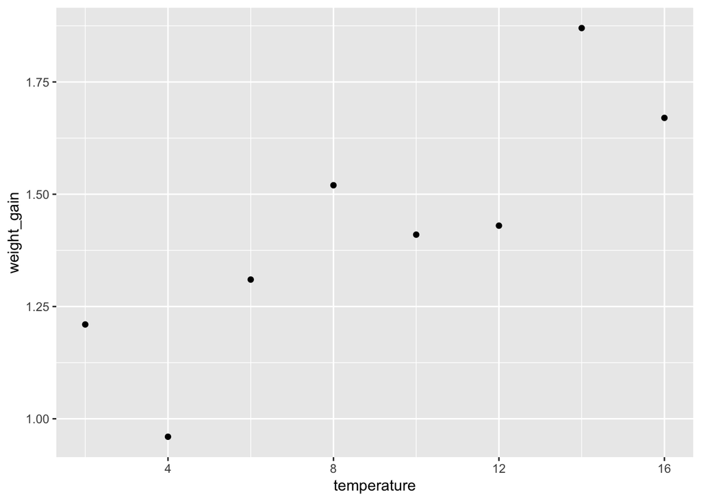

```r
ggplot(insect_dat, aes(x = temperature, y = weight_gain)) +
  geom_point()
```

Inspecting a scatter plot of the data is valuable for several reasons, even if you already know the correlation between two variables:

1. **Visual Confirmation**: While correlation coefficients provide a numerical measure of the strength and direction of the relationship between two variables, a scatter plot allows you to visually confirm this relationship. Sometimes, the correlation coefficient might indicate a weak relationship, but upon visual inspection, you might notice a clear pattern or non-linear trend in the data that was not apparent from the correlation alone.

2. **Outlier Detection**: Scatter plots help in identifying outliers, which are data points that deviate significantly from the overall pattern of the data. Outliers can have a disproportionate influence on the correlation, potentially skewing the interpretation of the relationship between variables.

3. **Contextual Understanding**: Viewing the actual data points on a scatter plot provides a richer understanding of the relationship between variables within the specific context of the dataset. This understanding can be crucial for making informed decisions or drawing meaningful conclusions from the data.

4. **Communication**: Scatter plots are often used for communication purposes, as they provide a clear and intuitive way to visualize the relationship between variables. They can be included in reports, presentations, or academic papers to effectively convey insights from the data to a broader audience.